# Sistemas de ecuaciones diferenciales ordinarias

**Alumno**: Mario Rodríguez Félix

**Profesor**: Dra. Briceyda B. Delgado López

```python
import numpy as np
import pandas as pd
import matplotlib.pyplot as plt
import seaborn as sns
import sympy as sp
```

# Sistema de ecuaciones diferenciales

$$F'(t)=(2-S(t))F(t), \qquad F(0)=F_{0}$$

$$S'(t)=(F(t)-1)S(t), \qquad S(0)=S_{0}$$

# Ejercicio 1

A partir de las ecuaciones anteriores tenemos que: $$ \frac{d{F}}{(2-S)F} = d{t} \qquad , \qquad \frac{dS}{(F-1)S} = dt$$ Por lo que: $$ \frac{d{F}}{(2-S)F} = \frac{dS}{(F-1)S} $$ Y a variables separables: $$ \frac{(2-S)}{S}dS = \frac{(F-1)}{F}dF $$ Si integramos cada parte de la igualdad obtenemos:

```python
# Integrando los elementos de la ecuación anterior
S, F = sp.symbols("S F")
integral_S = sp.integrate(((2-S)/S), S)
integral_F = sp.integrate(((F-1)/F), F)
```

```python
# Resultado de la integral
sp.Eq(integral_S, integral_F)
```

$\displaystyle - S + 2 \log{\left(S \right)} = F - \log{\left(F \right)}$

Reordenando los elementos de la ecuación, definiendo a **$ \hspace{0.1cm} "e" \hspace{0.1cm} $** como la base de los logaritmos y agregando la constante de integración: $$ 2ln(S) - S = F - ln(F) + C $$ Obteniendo el valor de C a partir de las condiciones iniciales $ F(0) = F_{0} $ , $ \hspace{0.2cm} S(0) = S_{0} $: $$ 2ln(S_{0}) - S_{0} = F_{0} - ln(F_{0}) + C $$ $$ C = 2ln(S_{0}) - S_{0} + ln(F_{0}) - F_{0} $$ Se obtiene la solución analítica implícita en términos de las condiciones iniciales: $$ 2ln(S) - S = F - ln(F) + (2ln(S_{0}) - S_{0} + ln(F_{0}) - F_{0}) $$

# Ejercicio 2

A partir del sistema de ecuaciones diferenciales anterior, discretizamos el problema tomando un entero $N \geq 1$ y definiendo los saltos en el tiempo como: $$\Delta{t} = \frac{T}{N}$$ Y los niveles de tiempo como: $$t_{n} = n\Delta{t}$$ para todo $n = 0, 1, 2, ..., N \quad$ y $\quad t_{0} = 0 \quad$ y $ \quad t_{N} = T$.

Establecemos que $F_{n}$ es una aproximación de $F(t_{n})$

Para derivar una aproxiamción de la solución de $$F'(t)=(2-S(t))F(t)$$ Se usa la serie de Taylor de manera que: $$F(t + \Delta{t}) = F(t) + \Delta{t}F'(t) + O(\Delta{t^2})$$ Despejando $F'(t)$: $$F'(t) = \frac{F(t + \Delta{t}) - F(t)}{\Delta{t}} + O(\Delta{t})$$ Si se establece esta observación para el momento en el que $t = t_{n}$ y puesto que se busca establecer un $\Delta{t} \approx 0$ se espera que $O(\Delta{t}) \approx 0$ por lo que: $$F'(t_{n}) = \frac{F(t_{n+1}) - F(t_{n})}{\Delta{t}}$$ Y dado que $F_{n} \approx F(t_{n})$: $$F'_{n} = \frac{F_{n+1} - F_{n}}{\Delta{t}}$$ Y despejando $F_{n+1}$ $$F_{n+1} = F_{n} + \Delta{t}F'_{n}$$ Puesto que $F'(t) = (2-S(t))F(t)$: $$F_{n+1} = F_{n} + \Delta{t}(2-S_{n})F_{n}$$

Siguiendo el mismo razonamiento obtenemos la aproximación numérica de $S'(t)$: $$S_{n+1} = S_{n} + \Delta{t}(F_{n} - 1)S_{n}$$

## Ejercicio 3

### a)

```python
# Se crea una función que recibe como argumentos a
# los valores iniciales S0, F0, los pasos en el
# tiempo delta_t y total de tiempo T
def aproximacion_numerica(f0, s0, dt, T):
    N = int(T / dt)

    F = np.zeros(N + 1)
    S = np.zeros(N + 1)

    F[0] = f0
    S[0] = s0

    for n in range(N):
        F[n + 1] = F[n] + dt * (2 - S[n]) * F[n]
        S[n + 1] = S[n] + dt * (F[n] - 1) * S[n]

    return F, S
```

### b)

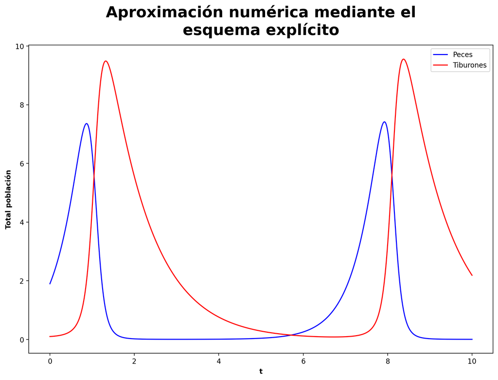

```python
# Se establecen los valores bajo los cuál se va
# a realizar el cálculo de la aproximación
f0 = 1.9
s0 = 0.1
dt = 1 / 1000
T = 10
N = int(T / dt) + 1

# Se calcula la solución numérica
F, S = aproximacion_numerica(f0, s0, dt, T)

# Se definen un intervalo que contiene la cantidad
# total de "pasos" que se darán en el tiempo
t = np.linspace(0, T, N)

# Se genera la gráfica con los resultados de la aproximación numérica
plt.figure(figsize=(12, 8), dpi=200)
sns.lineplot(x=t, y=F, color="blue", label="Peces")
sns.lineplot(x=t, y=S, color="red", label="Tiburones")
plt.title(
    "Aproximación numérica mediante el\nesquema explícito",
    fontsize=22,
    fontweight="bold",
    y=1.02,
)
plt.ylabel("Total población", fontweight="bold")
plt.xlabel("t", fontweight="bold")
plt.legend()
plt.show()
```

Se puede observar que hay un comportamiento cíclico entre depredador y presa. Cuando la población de presas supera a la de depredadores, estos últimos tienen las condiciones para incrementar su propia población, sin embargo, a medida que esta incrementa, se va diezmando la población de las presas, lo que proboca que la población de depresadores disminuya y crezca nuevamente la de presas para así reiniciar el cílco.

Es importante mencionar que en esta simulación estamos tomando el supuesto de condiciones ilimitadas para el crecimiento de la población de las presas. Cuando se define una capacidad de carga, es decir, un límite en los recursos para el crecimeinto de la población de las presas, se observa un comportamiento distinto a este, concretamente se tienda a un estado estacionario en donde la población tanto de presas como de depredadores se mantienen constantes.